# Survey Data Analysis Report: Influence of Background Music on Study Performance (Enhanced)

Group 39

June 26, 2025

# 1 Introduction

In this report, we want to analyze whether the genre of background music has an impact on students’ study performance. The hypothesis is that studying with low-tempo instrumental music helps complete comprehension tasks more accurately and quickly compared to studying with lyrical music or in silence. To test this, we have prepared three survey questions as follows:

- Q1: Type of background music while studying (None, Instrumental, Music with lyrics, Other).
- Q2: Focus level while studying with preferred music (1 to 10 scale).
- Q3: Time to complete a typical comprehension assignment (in minutes).

This enhanced analysis uses R for data cleaning, comprehensive exploratory data analysis (EDA), descriptive inference, analytic inference, and crucial assumption checks for statistical tests. Key R packages used include `dplyr`, `ggplot2`, `knitr`, `readxl`, `car`, `ggpubr`, and `broom`.

# 2 Data Cleaning

The dataset, is in Exel format (`group39.xlsx`), contains demographic and survey responses. Data cleaning steps address inconsistencies, missing values, and outliers.

- **Renaming Columns:** Columns are renamed for clarity (e.g., DemographicAnswer.1 to Gender, Answer.1 to MusicType).
- **Handling Missing Values:** Rows with missing `MusicType` are removed, as this is critical for RQ1.
- **Outlier Removal:** For `TimeToComplete` (Q3), extreme values (e.g., 99999999 minutes) are treated as outliers and removed. Values above 360 minutes (6 hours) are considered unrealistic for a typical assignment. This helps ensure the statistical analysis is not skewed by erroneous entries.
- **Type Conversion:** `FocusLevel` (Q2) is converted to numeric, and `TimeToComplete` is cleaned to handle non-numeric entries.

```r
library(readxl)
library(dplyr)
data <- read_excel("group39.xlsx")

# renaming columns
data <- data %>%
  rename(Gender = DemographicAnswer.1,
         Age = DemographicAnswer.2,
         Education = DemographicAnswer.3,
         MusicType = Answer.1,
         FocusLevel = Answer.2,
         TimeToComplete = Answer.3)

# removing the rows which has missing MusicType
data <- data %>% filter(!is.na(MusicType))

# converting focusLevel to numeric
data$FocusLevel <- as.numeric(as.character(data$FocusLevel))

# cleaning TimeToComplete: handling ranges and outliers
# Convert "10-15" to "12.5" and then to numeric
data$TimeToComplete <- gsub("10-15", "12.5", data$TimeToComplete)
data$TimeToComplete <- as.numeric(as.character(data$TimeToComplete))

# removing extreme outliers
data <- data %>% filter(TimeToComplete <= 360 | is.na(TimeToComplete))
data <- data %>% filter(TimeToComplete != 999999999 | is.na(TimeToComplete))

data$MusicType <- as.factor(data$MusicType)
```

# 3 Exploratory Data Analysis

Exploratory Data Analysis examines the distribution of key variables and their relationships to address RQ1, providing more detailed insights into the data’s characteristics.

## 3.1 Distribution of Music Type

A bar plot shows the frequency of each music type.

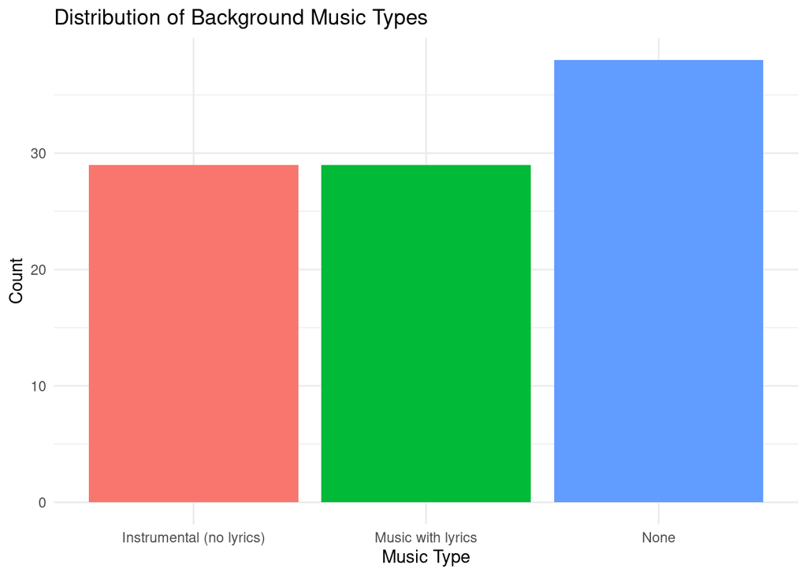

```r
library(ggplot2)
ggplot(data, aes(x = MusicType, fill = MusicType)) +
  geom_bar() +
  labs(title = "Distribution of Background Music Types",
       x = "Music Type",
       y = "Count") +
  theme_minimal() +
  theme(legend.position = "none")
```

This plot shows the sample size for each music type, which is important for interpreting statistical test results later.

## 3.2 Completion Time by Background Music Type

A boxplot visualizes TimeToComplete by MusicType to compare completion times across music genres, providing a clear visual representation of central tendency and spread.

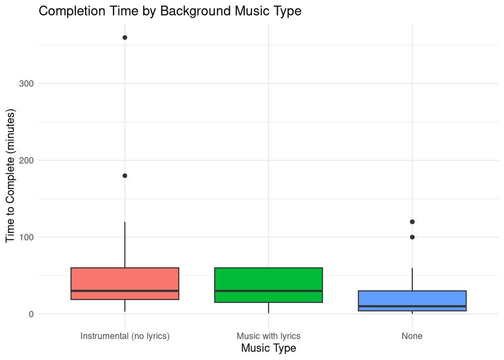

```r
library(ggplot2)
ggplot(data, aes(x = MusicType, y = TimeToComplete, fill = MusicType)) +
  geom_boxplot() +
  labs(title = "Completion Time by Background Music Type",
       x = "Music Type",
       y = "Time to Complete (minutes)") +
  theme_minimal() +
  theme(legend.position = "none")
```

according to the boxplot, when students lesten to the musice, they need more time to complete their task. Type of music are not different a lot.

## 3.3 Focus Level by Background Music Type

A boxplot for FocusLevel by MusicType helps visualize differences in self-reported focus.

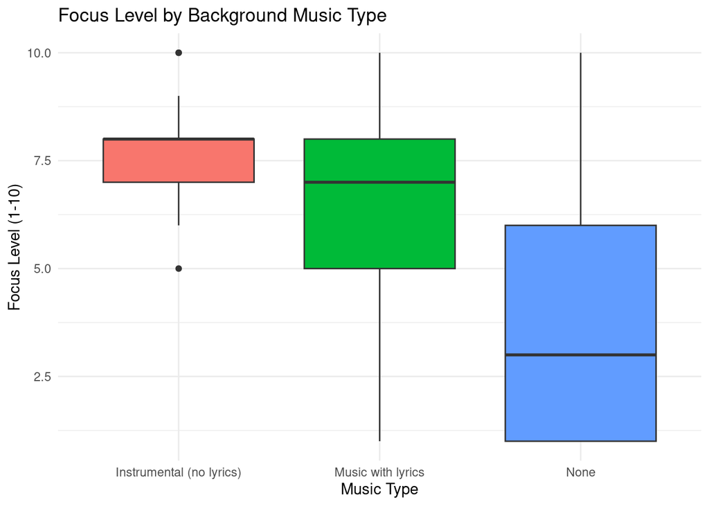

```r
ggplot(data, aes(x = MusicType, y = FocusLevel, fill = MusicType)) +
  geom_boxplot() +
  labs(title = "Focus Level by Background Music Type",
       x = "Music Type",
       y = "Focus Level (1-10)") +
  theme_minimal() +
  theme(legend.position = "none")
```

This plot provides a visual comparison of focus levels across different music types. Instrumental music appears to be associated with slightly higher median focus levels.

## 3.4 Distribution of Numerical Variables

Histograms for FocusLevel and TimeToComplete show their overall distributions.

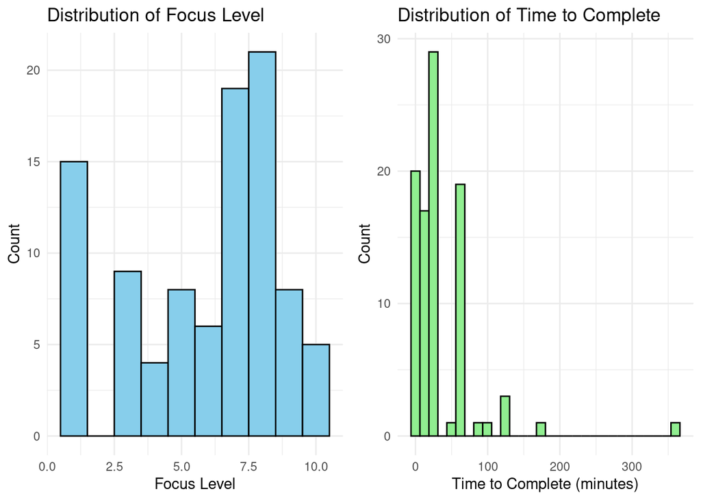

```r
library(cowplot) # For combining plots

p1 <- ggplot(data, aes(x = FocusLevel)) +
  geom_histogram(binwidth = 1, fill = "skyblue", color = "black") +
  labs(title = "Distribution of Focus Level", x = "Focus Level", y = "Count") +
  theme_minimal()

p2 <- ggplot(data, aes(x = TimeToComplete)) +
  geom_histogram(fill = "lightgreen", color = "black") +
  labs(title = "Distribution of Time to Complete", x = "Time to Complete (minutes)", y = "Count") +
  theme_minimal()

plot_grid(p1, p2, ncol = 2)
```

These histograms provide insights into the overall spread and skewness of the numerical variables, which is useful for assessing normality assumptions later.

# 4 Descriptive Inference

Summary statistics for FocusLevel and TimeToComplete are computed for each MusicType, now presented with more detail including median and interquartile range to complement mean and standard deviation, which are more robust to outliers.

```r
library(knitr)
library(dplyr)

summary_stats <- data %>%
  group_by(MusicType) %>%
  summarise(
    N = n(),
    Mean_Focus = mean(FocusLevel, na.rm = TRUE),
    SD_Focus = sd(FocusLevel, na.rm = TRUE),
    Median_Focus = median(FocusLevel, na.rm = TRUE),
    IQR_Focus = IQR(FocusLevel, na.rm = TRUE),
    Mean_Time = mean(TimeToComplete, na.rm = TRUE),
    SD_Time = sd(TimeToComplete, na.rm = TRUE),
    Median_Time = median(TimeToComplete, na.rm = TRUE),
    IQR_Time = IQR(TimeToComplete, na.rm = TRUE)
  )

print(summary_stats)
```

```
## # A tibble: 3 × 10
##   MusicType       N Mean_Focus SD_Focus Median_Focus IQR_Focus Mean_Time SD_Time
##   <fct>       <int>      <dbl>    <dbl>        <dbl>     <dbl>     <dbl>   <dbl>
## 1 Instrument…    29       7.79     1.15            8         1      52.6    71.2
## 2 Music with…    29       6.72     2.15            7         3      33.1    21.6
## 3 None           38       3.68     2.69            3         5      24.2    32.9
## # ℹ 2 more variables: Median_Time <dbl>, IQR_Time <dbl>
```

# 5 ANOVa

We check the normality of the residuals from the ANOVA model. This can be done visually with a QQ plot.

```r
library(car)
```

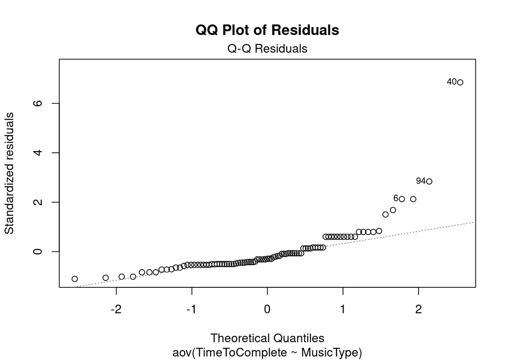

```r
# Build the linear model for ANOVA
anova_model <- aov(TimeToComplete ~ MusicType, data = data)

# QQ plot of residuals
plot(anova_model,2)
title("QQ Plot of Residuals")
```

```r
print(anova_model)
```

```
## Call:
##    aov(formula = TimeToComplete ~ MusicType, data = data)
##
## Terms:
##                 MusicType Residuals
## Sum of Squares    12969.5  187906.5
## Deg. of Freedom         2        90
##
## Residual standard error: 45.693
## Estimated effects may be unbalanced
## 3 observations deleted due to missingness
```

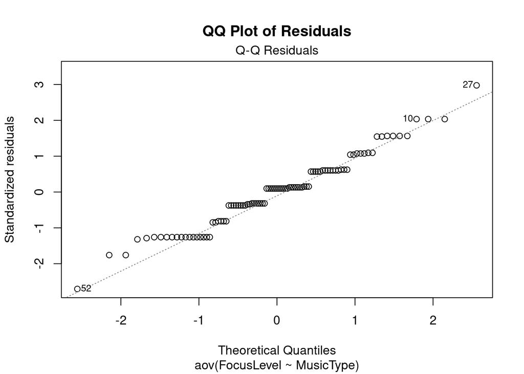

```r
library(car)

# Build the linear model for ANOVA
anova_model_focous <- aov(FocusLevel ~ MusicType, data = data)

# QQ plot of residuals
plot(anova_model_focous,2)
title("QQ Plot of Residuals")
```

```r
print(anova_model_focous)
```

```
## Call:
##    aov(formula = FocusLevel ~ MusicType, data = data)
##
## Terms:
##                 MusicType Residuals
## Sum of Squares   306.5612  426.6598
## Deg. of Freedom         2        92
##
## Residual standard error: 2.15351
## Estimated effects may be unbalanced
## 1 observation deleted due to missingness
```

## 5.1 Performing ANOVA

```r
library(broom)
summary_anova <- summary(anova_model)

# Displaying ANOVA results
kable(tidy(anova_model), caption = "ANOVA Results for Completion Time by Music Type",
             format = "latex", booktabs = TRUE, digits = 3)
```

[output not shown]

```r
# Post-hoc test if overall ANOVA is significant
if (summary_anova[[1]][["Pr(>F)"]][1] < 0.05) {
  message("Performing TukeyHSD post-hoc test due to significant ANOVA result:")
  tukey_result <- TukeyHSD(anova_model)
  print(tukey_result)
} else {
  message("ANOVA not significant, no post-hoc test needed.")
}
```

```
## Performing TukeyHSD post-hoc test due to significant ANOVA result:
```

```
##   Tukey multiple comparisons of means
##     95% family-wise confidence level
##
## Fit: aov(formula = TimeToComplete ~ MusicType, data = data)
##
## $MusicType
##                                                 diff       lwr        upr
## Music with lyrics-Instrumental (no lyrics) -19.55542 -48.40580  9.2949624
## None-Instrumental (no lyrics)              -28.41270 -55.85066 -0.9747357
## None-Music with lyrics                      -8.85728 -36.02784 18.3132791
##                                                p adj
## Music with lyrics-Instrumental (no lyrics) 0.2444661
## None-Instrumental (no lyrics)              0.0406499
## None-Music with lyrics                     0.7181424
```

The ANOVA tests whether mean completion times differ significantly across music types. A p-value less than 0.05 indicates a statistically significant difference among group means. If significant, the TukeyHSD post-hoc test identifies which specific pairs of music types have significantly different mean completion times. But this results are not reliable. We perform another test.

## 6 Kruskal-Wallis Rank Sum Test

If the assumptions for ANOVA are violated, the Kruskal-Wallis rank sum test is a non-parametric alternative. It tests if there are significant differences in the medians among groups.

```r
# Kruskal-Wallis Rank Sum Test
kruskal_result <- kruskal.test(TimeToComplete ~ MusicType, data = data)
print(kruskal_result)
```

```
##
##  Kruskal-Wallis rank sum test
##
## data:  TimeToComplete by MusicType
## Kruskal-Wallis chi-squared = 11.543, df = 2, p-value = 0.003116
```

```r
# If significant, conduct Dunn's test for post-hoc analysis (requires DescTools package)
# Make sure DescTools is installed: install.packages("DescTools")
library(DescTools)
if (kruskal_result$p.value < 0.05) {
  message("Performing Dunn's post-hoc test due to significant Kruskal-Wallis result:")
  dunn_result <- DescTools::DunnTest(TimeToComplete ~ MusicType, data = data, method="bonferroni")
  print(dunn_result)
}
```

```
## Performing Dunn's post-hoc test due to significant Kruskal-Wallis result:
```

```
##
##  Dunn's test of multiple comparisons using rank sums : bonferroni
##
##                                            mean.rank.diff   pval
## Music with lyrics-Instrumental (no lyrics)      -4.662562 1.0000
## None-Instrumental (no lyrics)                  -21.339286 0.0046 **
## None-Music with lyrics                         -16.676724 0.0372 *
## ---
## Signif. codes:  0 '***' 0.001 '**' 0.01 '*' 0.05 '.' 0.1 ' ' 1
```

There is a significant effect of music type on task completion time. Specifically, working without music results in faster performance than working with either type of music (instrumental or with lyrics). However, the type of music (instrumental vs. lyrical) does not significantly affect performance between each other.

```r
# Kruskal-Wallis Rank Sum Test
kruskal_result_Focous <- kruskal.test(FocusLevel ~ MusicType, data = data)
print(kruskal_result_Focous)
```

```
##
##  Kruskal-Wallis rank sum test
##
## data:  FocusLevel by MusicType
## Kruskal-Wallis chi-squared = 36.405, df = 2, p-value = 1.244e-08
```

```r
# If significant, conduct Dunn's test for post-hoc analysis (requires DescTools package)
# Make sure DescTools is installed: install.packages("DescTools")
library(DescTools)
if (kruskal_result_Focous$p.value < 0.05) {
  message("Performing Dunn's post-hoc test due to significant Kruskal-Wallis result:")
  dunn_result_Focous <- DescTools::DunnTest(FocusLevel ~ MusicType, data = data, method="bonferroni")
  print(dunn_result_Focous)
}
```

```
## Performing Dunn's post-hoc test due to significant Kruskal-Wallis result:
```

```
##
##  Dunn's test of multiple comparisons using rank sums : bonferroni
##
##                                            mean.rank.diff    pval
## Music with lyrics-Instrumental (no lyrics)      -11.75862 0.29991
## None-Instrumental (no lyrics)                   -39.12488   2e-08 ***
## None-Music with lyrics                          -27.36626 0.00015 ***
## ---
## Signif. codes:  0 '***' 0.001 '**' 0.01 '*' 0.05 '.' 0.1 ' ' 1
```